# Unconventional Monetary Policies and Inequality in the EU

#### Analysis

```python
# Creating my variables
x_y = np.array(filtered_data)
GINI, GINIt1,GINIt2,Credit_GDP,GDP_growth,Inflation, FDI_GDP, UMP =x_y[:,2], x_y[:,3], x_y[:,4], x_y[:,5],x_y[:,6], x_y[:,7],x_y[:,8], x_y[:,9]
```

```python
# Shaping my variables into vectors
GINI, UMP, GINIt1,GINIt2,Credit_GDP,GDP_growth,Inflation, FDI_GDP  = GINI.reshape(-1,1), UMP.reshape(-1,1), GINIt1.reshape(-1, 1),  GINIt2.reshape(-1,1), Credit_GDP.reshape(-1, 1), GDP_growth.reshape(-1,1), Inflation.reshape(-1, 1), FDI_GDP.reshape(-1,1)
```

As we can see here, there is a strong linear relationship between the GINI index and its two lags. So it makes sense to include them in the model.

```python
# Let's see the relationship between my dependent variable and its first lag
lin_regression = LinearRegression()
lin_regression.fit(GINIt1.astype(float).reshape(-1,1),GINI.astype(float).reshape(-1,1))
m = lin_regression.coef_[0]
b = lin_regression.intercept_
print('equation: GINI = {0}GINIt1 + {1}'.format(m,b))
```

```
equation: GINI = [ 0.95848278]GINIt1 + [ 1.23783122]
```

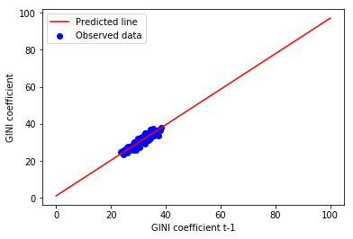

```python
# This is the graph of the previous equation
plt.scatter(GINIt1.astype(float), GINI.astype(float),  color='blue')
plt.plot([0,100],[b,m*100+b],'r')
plt.yticks([0,20,40,60,80,100])
plt.xticks([0,20,40,60,80,100])
plt.xlabel('GINI coefficient t-1')
plt.ylabel('GINI coefficient')
plt.legend(['Predicted line','Observed data'])
plt.show()
```

```python
# Let's see the relationship between my dependent variable and its second lag
lin_regression = LinearRegression()
lin_regression.fit(GINIt2.astype(float).reshape(-1,1),GINI.astype(float).reshape(-1,1))
m = lin_regression.coef_[0]
b = lin_regression.intercept_
print('equation: GINI = {0}GINIt2 + {1}'.format(m,b))
```

```
equation: GINI = [ 0.93240828]GINIt2 + [ 2.09777553]
```

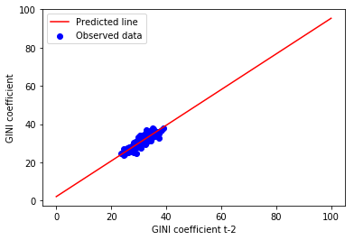

```python
# This is the graph of the previous equation
plt.scatter(GINIt2.astype(float), GINI.astype(float),  color='blue')
plt.plot([0,100],[b,m*100+b],'r')
plt.yticks([0,20,40,60,80,100])
plt.xticks([0,20,40,60,80,100])
plt.xlabel('GINI coefficient t-2')
plt.ylabel('GINI coefficient')
plt.legend(['Predicted line','Observed data'])
plt.show()
```

###### Regression

```python
# Creating dependent and independent variables for my multiple regression
target1 = pd.DataFrame(filtered_data,columns=["GINI"])
predictors1=pd.DataFrame(filtered_data,columns=['UMP','GINIt-1','GINIt-2','Credit_GDP','Credit_GDP','GDP_growth','Inflation','FDI_GDP'])
# Regression
mult_regression = LinearRegression()
mult_regression.fit(predictors1,target1)
```

[output not shown]

```python
# Creating dependent and independent variables for my multiple regression
target = pd.DataFrame(filtered_data,columns=["GINI"])
predictors=pd.DataFrame(filtered_data,columns=['UMP','GINIt-1','GINIt-2'])
```

```python
# Regression
mult_regression = LinearRegression()
mult_regression.fit(predictors,target)
```

```
LinearRegression(copy_X=True, fit_intercept=True, n_jobs=1, normalize=False)
```

```python
# Coefficients
mult_regression.coef_
```

```
array([[-0.01364543,  0.92372876,  0.03703152]])
```

```python
# Intercept
mult_regression.intercept_
```

```
array([ 1.20296309])
```

The estimated regression is thus: $$ Gini_{i,t} = 1.20296309 - 0.01364543 UMP_t + 0.92372876 Gini_{i,t-1} + 0.03703152 Gini_{i,t-2}.$$

#### Results

As we can see from the sign of the coefficient of $UMP_t$ in the regression, the presence of unconventional policies had a negative impact on the [Gini index](https://www.investopedia.com/terms/g/gini-index.asp). Since a lower Gini index means a lower inequality, there is evidence of a positive redistribution of incomes. This must not be confused, though, as a general increase of wealth: for instance, inequality may be decreased as a result of lower high incomes.

## Robustness

```python
# Creating dependent and independent variables for my multiple regression
robtarget = pd.DataFrame(filtered_data,columns=["GINI"])
robpredictors=pd.DataFrame(filtered_data,columns=['UMP','GINIt-1','GINIt-2','Credit_GDP','GDP_growth','Inflation','FDI_GDP'])
# Regression
mult_regression = LinearRegression()
mult_regression.fit(robpredictors,robtarget)
```

```
LinearRegression(copy_X=True, fit_intercept=True, n_jobs=1, normalize=False)
```

```python
# Coefficients
mult_regression.coef_
```

```
array([[ 0.02584784,  0.87556172,  0.07286237,  0.00209014, -0.05558743,
         0.02873237,  0.00437564]])
```

```python
# Intercept
mult_regression.intercept_
```

[output not shown]

#### Results

From what we see, the presence of unconventional monetary policy raised inequality. The coefficient of my variable of interest - $UMP_t$ - is indeed positive.

## Discussion

The opposite results may be due to the fact that in the second model I included more variables which are high-effective predictors of income inequality. Here, the results make more sense if we consider how unconventional policies work: they simply provide the creation of wealth through injection of money in the markets or in the banking system. Usually, the users of these channels already own a high level of wealth, and as a result they become even richer if compared to the poor. Of course, over the years, such increase of richness will be redistributed to the lower income-classes for example through higher consumptions, but this requires time. To date, maybe the policies are so recent that, in the second and probably more reliable regression I have run, we can not observe positive redistributive effects.

# Final Considerations

One of the main weakness of my research is the lack of data following the introduction of [QE](https://www.ecb.europa.eu/explainers/show-me/html/app_infographic.en.html) in 2015. So I may underestimate or not estimate at all the effects of such policy. This is an issue to address in future analysis considering, the impact that QE had on the eurozone economy and its monetary amount.

Furthermore, the econometric model I designed could be surely improved. The use of a dummy variable to test for the effects of the unconventional monetary policies is probably not precise enough. The best strategy would be to create different variables for each policy, using country- and time-specific data for the quantity of money that injected. Here, again, the problem I faced was a lack of data, since many financial institutions did not share how much money they borrowed, as such amount could be a signal of financial distress.